# Riparian Invertebrates: Investigate Methods

## Field data

Import previously prepared field data. Here are 10 random rows from the data:

```
## # A tibble: 10 x 17
##    spp_name    abund_num abund_char river  event    event_code date   year
##    <chr>           <int> <chr>      <chr>  <chr>    <chr>      <chr> <int>
##  1 Bembidion ~        NA <NA>       Wye    Wye 4 2~ Wye_2014_4 31/1~  2015
##  2 Bembidion ~        19 <NA>       Carey  Carey 1~ Carey_200~ 25/0~  2002
##  3 Hydrosmect~         1 <NA>       Rheid~ Rheidol~ Rheidol_2~ 01/0~  2004
##  4 Bembidion ~         6 <NA>       Towy   Towy 3 ~ Towy_2003~ 08/0~  2002
##  5 Phaedon ar~        NA <NA>       Frome  River F~ FromeRush~ 08/0~  2017
##  6 Amara aenea        NA <NA>       Monnow Monnow ~ Monnow_20~ 01/0~  2015
##  7 Elaphrus c~        NA <NA>       Frome  River F~ FromeMore~ 09/0~  2017
##  8 Coccinella~        NA <NA>       Wye    Wye 6 2~ Wye_2014_6 01/0~  2015
##  9 Glisrochil~        NA <NA>       Lugg   Lugg 20~ Lugg_2014~ 01/0~  2015
## 10 Zorochros ~       139 <NA>       Carey  Carey 1~ Carey_200~ 25/0~  2002
## # ... with 9 more variables: sample_type <chr>, location <chr>,
## #   repl_dateloc <chr>, repl_date <chr>, repl_loc <chr>,
## #   sadler_bell <chr>, search_pitfall <chr>, search_excavation <chr>,
## #   sample_duration <chr>
```

Each species record is a row. Columns are abundance (very inconsistently used) and data about the survey.

The data is nested as follows:

- `river`
- `event` or `event_code`, note that `year` is part of the definition of `event`
- `sample_type`
- replicate (see below for more on that)
- observation, i.e. `spp_name` and `abund_num` or `abund_char` depending on whether abundance was recorded as a number or in words.

For this data we have conceptualised a replicate as being a single sampling occasion, e.g. a set of pitfall traps (from being set to being retrieved), a timed hand search or a timed excavation. A replicate is equivalent to an ‘effort’, discussed further below. As these sampling occasions aren’t specifically labelled in the data, we had to infer them from the available data.  
The most useful seeming fields were the `date` and `location` fields. The date field generally contained a single date (although also just a year, in which case I labelled it `NA`, or a range of dates, in wich case I selected the start date). A single `event` often had many `date`s associated with it, which suggests that these were separate sampling occasions. This was the case both for pitfall traps and for hand searches and excavations. The location field was populated in a substantial majority of the data, however it signified different things for different surveys. In some cases it merely stated the name of the river (e.g. `River Dove`), in other cases it appeared to specifically distinguish replicates (e.g. `1D` or `site A`).  
I tried using `date` (`repl_date`, 475 replicates) and `location` (`repl_loc`, 512 replicates) as proxies for replicate, and found that there was some overlap, but also a large ammount of difference. Finally I combined them into a single replicate field (`repl_dateloc`, 734 replicates). The risks of this method are:

1. This is a post-hoc stratification of the sample and may not represent the actual sampling methodology in many cases and may introduce bias.
2. The more the data is subdivided the smaller the average species richness per replicate (see hsitograms below). This is problematic if it does not concur with actual sampling methodology.

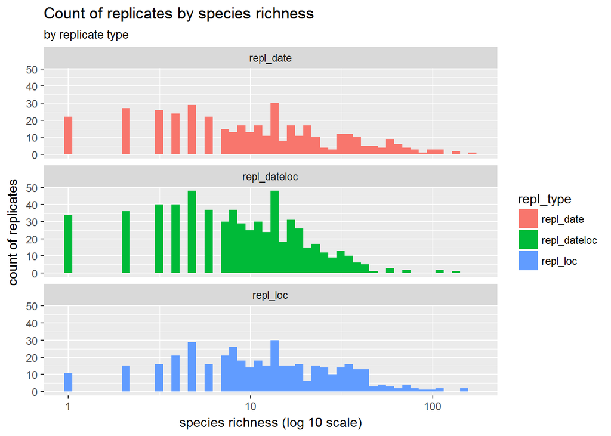

If it is possible to add a field which identifies the actual replicates in each survey these problems would be overcome.

## Sampling effort data

Sampling effort data is available from a study of the reported methodologies for each survey and have been compiled for analysis. An extract of the data is shown below. `effort_P` represents the number of pitfall trap samples. Note it does not represent the number of actual traps, rather a set of traps (quantity given in `n_pitfall` if known), set out for a period of time, e.g. 2 weeks, counts as 1 ‘effort’. `effort_T` represents the number of timed samples, both a timed hand search and a timed excavation count as 1 ‘effort’. `effort_combined` is simply the sum of `effort_P` and `effort_T`. The other columns are not currently being used for analysis (and I’m afraid the time period columns have been mangled in transition from excel to R - its possible to fix that, but wasn’t a priority).

```
## # A tibble: 10 x 14
##    event  event_code  author effort_P effort_T effort_combined effort_type
##    <chr>  <chr>       <chr>     <int>    <int>           <int> <chr>
##  1 Towy ~ Towy_2002_4 PhD r~        3        5               8 TP
##  2 Teign~ TeignBovey~ Sadle~        5        4               9 TP
##  3 Lugg ~ Lugg_2014_3 Hensh~        4        4               8 TP
##  4 Otter~ Otter_1999  Sadle~        3        3               6 TP
##  5 Sever~ Severn_200~ PhD r~        1        2               3 TP
##  6 Wye 6~ Wye_2014_6  Hensh~        4        4               8 TP
##  7 Yarty~ Yarty_1999  Sadle~        3        3               6 TP
##  8 Tywi ~ Tywi_1998   Sadle~        3        4               7 TP
##  9 Dove ~ Dove_2013   Webb ~        1        4               5 TP
## 10 Beami~ Beamish_20~ Webb ~        1        4               5 TP
## # ... with 7 more variables: n_pitfall <int>, `time period 1` <chr>, `time
## #   period 2` <chr>, `time period 3` <chr>, `time period 4` <chr>,
## #   n_records <int>, n_excavations <int>
```

The effort counts are in fact the same thing as the number of replicates of each sample type. Unfortunately, they don’t correspond well with the inferred replicates discussed above.

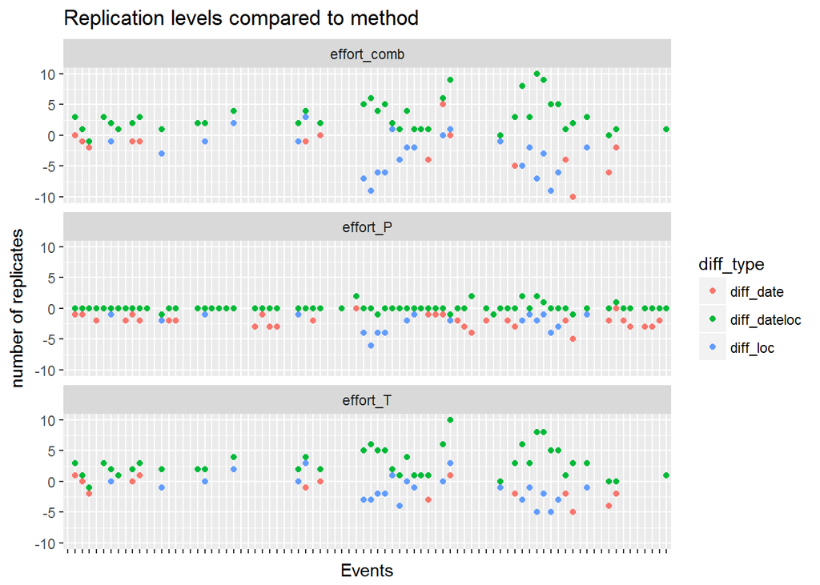

The above graph shows that replication levels depend on definition of replicate and for many events they vary from the method statement. The number of replicates given in the method for each survey (effort) is subtracted from number of replicates of each of the three type inferred from the data (colours). In the case of pitfall traps, there is a lot of agreement and `repl_dateloc` agrees in almost every case. For the timed searches it is harder to make a judgment.

The following `event`s are present in the effort data, but not in the cleaned field data: Fal, Lynher_2003_1, Plym_2003, EdenRead_2000_poss, Harwood_poss_1, Woolder_2013.

## Create frequency matrix

This matrix calculates the frequency each species occurs in each replicate.  
- because it’s by ‘replicate’ each species should only occur once, so in this case the frequency matrix is the same as an occurrence matrix.

```
##        river                               repl_dateloc      event_code
## 558      Wye               Wye 1 2014-HS-03062014-site1      Wye_2014_1
## 624    Yarty          Yarty 1999-PF-23061999-YartySite1      Yarty_1999
## 345     Tees         Tees 2 2008-HS-04082008-HolmeHouse     Tees_2008_2
## 188   Monnow     Monnow 2015-HS-02062015-Monnowsubsitea     Monnow_2015
## 323      Taw              Taw 1999-PF-24061999-TawSite1        Taw_1999
## 335     Tees    Tees 1 2008-PF-16082008-EgglestonBridge     Tees_2008_1
## 312     Tame River Tame 2000-EX-24082000-RiverTameSite2       Tame_2000
## 23  Breamish           Beamish 2013-HS-11062013-Beamish    Beamish_2013
## 10     Allen  Allen 1987 POSSIBLE-HS-NA-RiverAllenSite8 Allen_1987_poss
## 205     Plym           Plym 2002-HS-05062003-PlymBridge       Plym_2002
##     sample_type Abaxpara
## 558 hand_search        0
## 624     pitfall        0
## 345 hand_search        0
## 188 hand_search        0
## 323     pitfall        0
## 335     pitfall        1
## 312  excavation        0
## 23  hand_search        0
## 10  hand_search        0
## 205 hand_search        0
```

## Select events

Following discussion with Jon Webb we agreed to focus on a subset of events where there was a relatively high level of replication, and some variation within it. Jon suggested selecting surveys carried out by the following authors:

- Henshall et al
- Drewitt et al
- Webb & Mott

`sample_type` has been restricted to pitfall traps, hand searches and excavations.

These surveys are coded as the following events: Wye_2014_5, Beamish_2013, Dove_2013, Lugg_2014_2, Monnow_2015, FromeMoreton_2017, FromeRushton_2017, FromeWoodsford_2017, Till_2013, Wooler_2013, Wye_2014_1, Lugg_2014_1, Lugg_2014_3, Lugg_2014_4, Wye_2014_4, Wye_2014_6, Wye_2014_7, Wye_2014_3. In total these comprise 629. A breakdown of replicates by sample type (based on the inferred `repl_dateloc` definition of replicate), and also showing the reported replication level below:

```
## # A tibble: 19 x 7
## # Groups:   event_code [19]
##    author    event_code   effort_P effort_T pitfall hand_search excavation
##    <chr>     <chr>           <int>    <int>   <int>       <int>      <int>
##  1 Drewitt ~ FromeMoreto~        1        4       1          NA          2
##  2 Drewitt ~ FromeRushto~        1        4       1          NA          2
##  3 Drewitt ~ FromeWoodsf~        1        4       1          NA          1
##  4 Henshall~ Lugg_2014_1         4        4       4           9         NA
##  5 Henshall~ Lugg_2014_2         2        3       2           2         NA
##  6 Henshall~ Lugg_2014_3         4        4       4           8         NA
##  7 Henshall~ Lugg_2014_4         4        4       4          10         NA
##  8 Henshall~ Wye_2014_1          1        4       2           3          1
##  9 Henshall~ Wye_2014_3          4        5       4           9         NA
## 10 Henshall~ Wye_2014_4          4        4       4           6         NA
## 11 Henshall~ Wye_2014_5          0        2      NA           3         NA
## 12 Henshall~ Wye_2014_6          4        4       4           8         NA
## 13 Henshall~ Wye_2014_7          4        4       4           7         NA
## 14 Webb & M~ Beamish_2013        1        4       1           2          1
## 15 Webb & M~ Dove_2013           1        4       1          NA          1
## 16 Webb & M~ Monnow_2015         1        4       1           6          2
## 17 Webb & M~ Till_2013           1        4       1           3          1
## 18 Webb & M~ Woolder_2013        1        4      NA          NA         NA
## 19 <NA>      Wooler_2013        NA       NA       1           1         NA
```

*nb: I think Woolder and Wooler are the same survey but I can’t be sure because both rivers exist.*

Note that, as before, this doesn’t match the reported replication, see e.g. Lugg_2014_4 which reports 4 hand searches but I have inferred 10 replicates!

## Species accumulation curves

In this section I’ll start looking at species accumulation curves, with an emphasis on methodological differences. As discussed I’ve had to infer replication, and in most of these cases I’ll use the `repl_dateloc` replicates unless otherwise stated. Initially I’ll be comparing different ways of subdividing the data (mainly by sample type and/or replicate).

### Grand total accumulation

This doesn’t really tell us a lot, except that combining all sampling methods and all surveys doesn’t reach an asymptote. Because this covers a number of rivers and surveys, I’m not sure we need to read much into this.

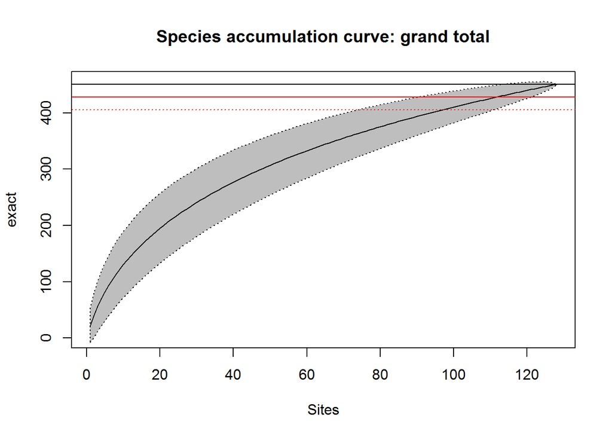

### Sample type accumulation

Here we’ll look at species accumulation curves by sample type. Can’t stress this enough: how we infer replicates is very likely to affect these results.

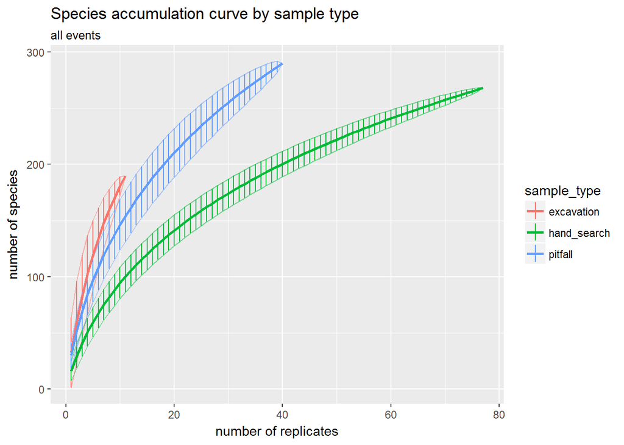

### Accumulation by event

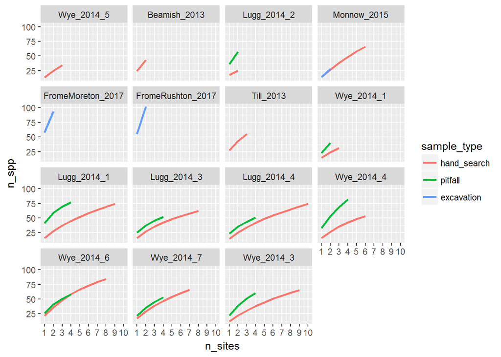

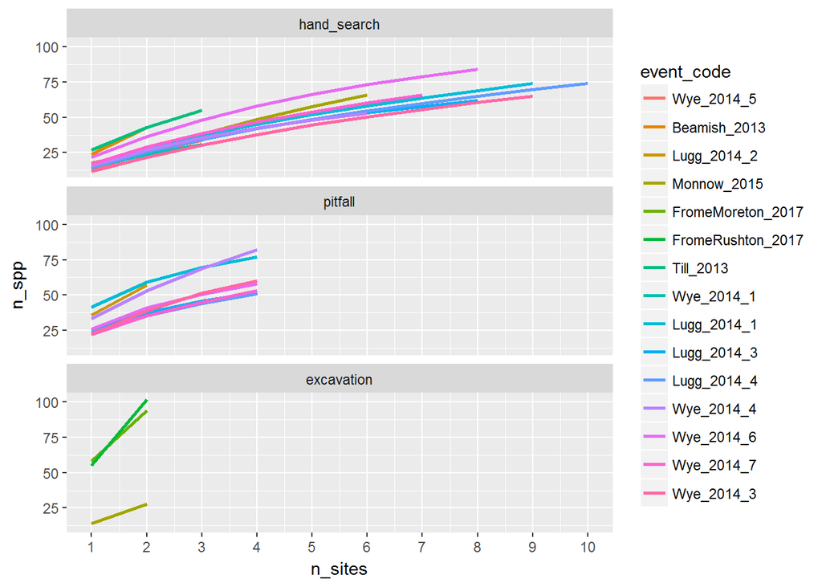